# Regression

Tyler B. Garner, tbg5023@psu.edu

Jennifer Valcin, jpv5319@psu.edu

2023-03-02

## Introduction

Regression analysis is one of the most fundamental and widely used statistical methods for modeling the relationship between variables. It involves identifying patterns and strengths of the relationship between one or more independent variables and a dependent variable. Regression models are extensively used in various fields, including finance, economics, social sciences, and engineering, to name a few. In this tutorial, we will start by introducing the basic concepts of regression analysis and gradually move on to more advanced techniques, such as multiple regression and logistic regression. By the end of this tutorial, you will have a solid understanding of the various regression methods in `R` and how to apply them to real-world problems.

```r
adm_df <- readRDS("data/interim/adm_df.RDS")

head(adm_df)
```

```
##   UniqueID GRE TOEFL SOP LOR  CGPA Research                 Discipline    Admit
## 1        1 337   118 4.5 4.5 3.892      yes              Science & Eng Accepted
## 2        2 324   107 4.0 4.5 3.580      yes              Science & Eng Accepted
## 3        3 316   104 3.0 3.5 3.232      yes            Applied Science Accepted
## 4        4 322   110 3.5 2.5 3.500      yes            Applied Science Accepted
## 5        5 314   103 2.0 3.0 3.316       no Humanities and Soc Science Accepted
## 6        6 330   115 4.5 3.0 3.768      yes              Science & Eng Accepted
```

## Linear regression

Linear regression is a statistical method used to model the relationship between a dependent variable and one or more independent variables with the goal of identifying a linear relationship that best describes the data. Linear regression makes several assumptions, including linearity, independence, normality, and equal variance of residuals. Its advantages include simplicity, interpretability, and its ability to model the relationship between variables. However, linear regression has some disadvantages, such as its inability to model nonlinear relationships and the risk of overfitting if the model is too complex or has too many predictors.

### Simple linear regression

Simple linear regression is a type of linear regression where there is only one independent variable that is used to predict the value of the dependent variable. It is a commonly used technique in statistical analysis and can be used to model and predict the relationship between variables in a simple and interpretable way.

Here, we will fit a simple linear regression model predicting GRE scores from cumulative GPA. We will supply the `lm()` function with two arguments, first a model formula and second our dataset.

```r
adm_fit <- lm(GRE ~ CGPA, adm_df)

summary(adm_fit)
```

```
##
## Call:
## lm(formula = GRE ~ CGPA, data = adm_df)
##
## Residuals:
##      Min       1Q   Median       3Q      Max
## -18.1453  -4.2984   0.5042   3.7769  26.7925
##
## Coefficients:
##             Estimate Std. Error t value Pr(>|t|)
## (Intercept)  177.695      4.641   38.29   <2e-16 ***
## CGPA          40.072      1.334   30.04   <2e-16 ***
## ---
## Signif. codes:  0 '***' 0.001 '**' 0.01 '*' 0.05 '.' 0.1 ' ' 1
##
## Residual standard error: 6.355 on 398 degrees of freedom
## Multiple R-squared:  0.694,  Adjusted R-squared:  0.6932
## F-statistic: 902.6 on 1 and 398 DF,  p-value: < 2.2e-16
```

#### Model diagnostics

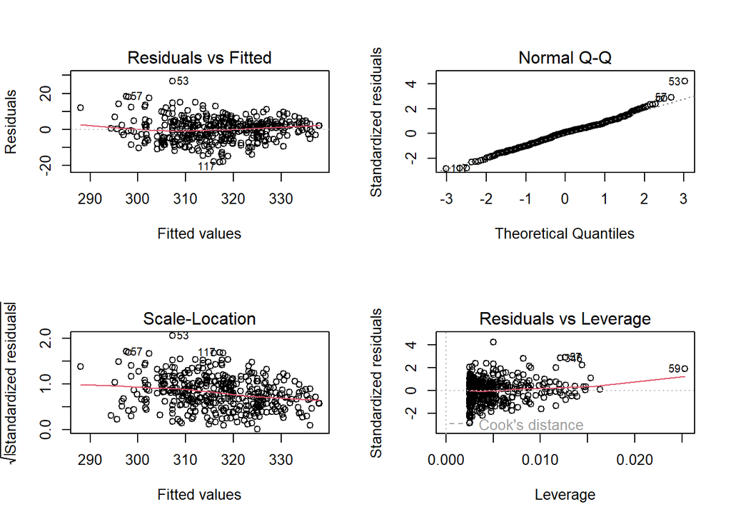

```r
par(mfrow = c(2, 2))
plot(adm_fit)
```

```r
par(mfrow = c(1, 1))
```

### Multiple linear regression

Multiple linear regression is a type of linear regression where there are two or more independent variables that are used to predict the value of the dependent variable. As multiple linear regression can be used to model the relationship between multiple predictors and the dependent variable, enabling more accurate predictions and more comprehensive analysis of the data, including potential interactions between variables.

Here, we will fit a linear regression model predicting GRE scores from cumulative GPA and TOEFL scores using the same functions and similar format as simple linear regression above.

```r
adm_fit2 <- lm(GRE ~ CGPA + TOEFL, data = adm_df)

summary(adm_fit2)
```

```
##
## Call:
## lm(formula = GRE ~ CGPA + TOEFL, data = adm_df)
##
## Residuals:
##      Min       1Q   Median       3Q      Max
## -16.2817  -3.5334   0.0755   3.6986  17.5367
##
## Coefficients:
##              Estimate Std. Error t value Pr(>|t|)
## (Intercept) 147.61133    4.98177   29.63   <2e-16 ***
## CGPA         21.54578    2.10361   10.24   <2e-16 ***
## TOEFL         0.87886    0.08267   10.63   <2e-16 ***
## ---
## Signif. codes:  0 '***' 0.001 '**' 0.01 '*' 0.05 '.' 0.1 ' ' 1
##
## Residual standard error: 5.614 on 397 degrees of freedom
## Multiple R-squared:  0.7618, Adjusted R-squared:  0.7606
## F-statistic: 634.8 on 2 and 397 DF,  p-value: < 2.2e-16
```

#### Model diagnostics

Diagnostic plots are a visual tool used to assess the validity of a linear regression model and identify any potential problems or violations of assumptions. There are several types of diagnostic plots, including:

- **Residuals vs. fitted** - used to check for linearity and homoscedasticity, as well as the presence of outliers. A pattern in the plot may indicate that the relationship between the dependent and independent variables is not linear or that the variance of the errors is not constant across the range of the data.
- **Q-Q** - used to check for normality of the residuals. A straight line in the plot indicates that the residuals are normally distributed, while deviations from the line indicate non-normality.
- **Scale-location** - used to check for homoscedasticity. A pattern in the plot may indicate that the variance of the residuals is not constant across the range of the data.
- **Residuals vs. leverage** - used to identify influential observations, which can have a large impact on the regression line. Observations with high leverage and high residuals are known as outliers and may need to be removed or further investigated.

When making inferences from linear models it is important to check the fit of the model, as violations of the model assumptions can lead to misleading results. The following code chunk creates a 2 x 2 graphical space to plot all four plots for our fitted model.

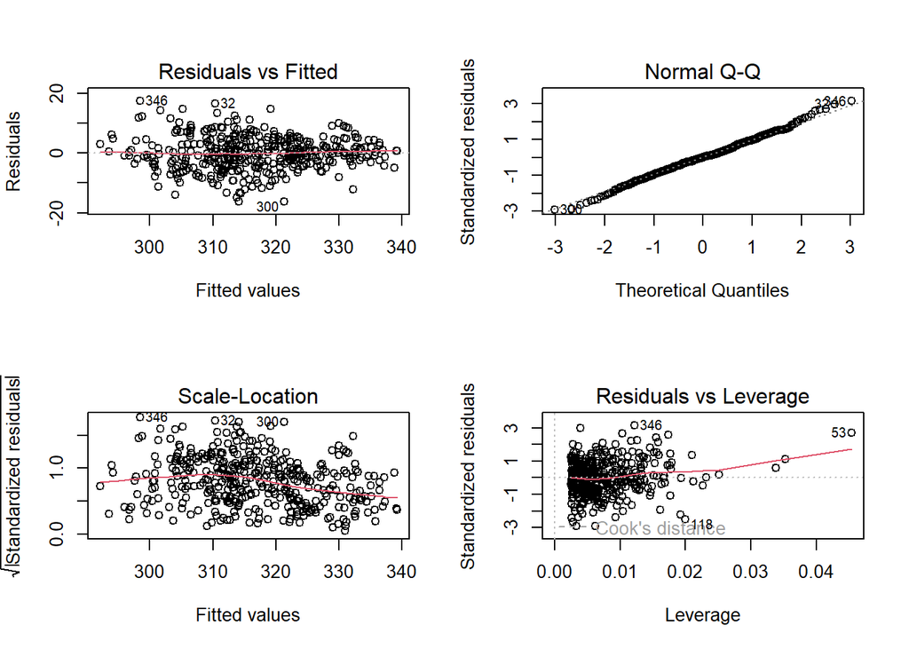

```r
par(mfrow = c(2, 2))
plot(adm_fit2)
```

```r
par(mfrow = c(1, 1))
```

Linear regression with all categorical variables is equivalent to ANOVA models, while regression with a mix of categorical and continuous variables is equivalent to ANCOVA models.

```r
adm_fit3 <- lm(GRE ~ CGPA + TOEFL + Discipline, data = adm_df)
summary(adm_fit3)
```

```
##
## Call:
## lm(formula = GRE ~ CGPA + TOEFL + Discipline, data = adm_df)
##
## Residuals:
##      Min       1Q   Median       3Q      Max
## -16.2393  -3.5015   0.0742   3.6068  17.4378
##
## Coefficients:
##                                       Estimate Std. Error t value Pr(>|t|)
## (Intercept)                          153.99136    6.98145  22.057   <2e-16 ***
## CGPA                                  20.40676    2.27849   8.956   <2e-16 ***
## TOEFL                                  0.85605    0.08457  10.123   <2e-16 ***
## DisciplineHumanities and Soc Science  -0.62418    0.75868  -0.823    0.411
## DisciplineScience & Eng                0.69157    0.80544   0.859    0.391
## ---
## Signif. codes:  0 '***' 0.001 '**' 0.01 '*' 0.05 '.' 0.1 ' ' 1
##
## Residual standard error: 5.616 on 395 degrees of freedom
## Multiple R-squared:  0.7628, Adjusted R-squared:  0.7604
## F-statistic: 317.6 on 4 and 395 DF,  p-value: < 2.2e-16
```

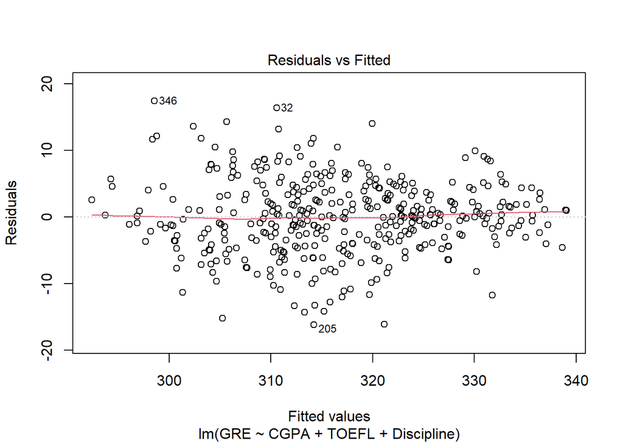

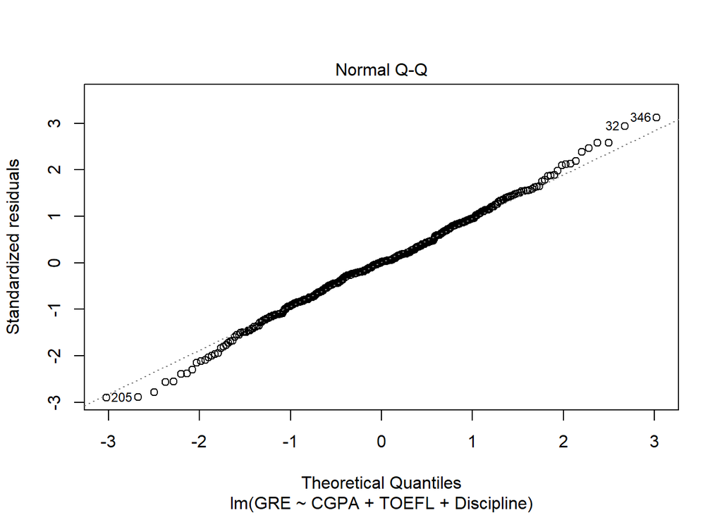

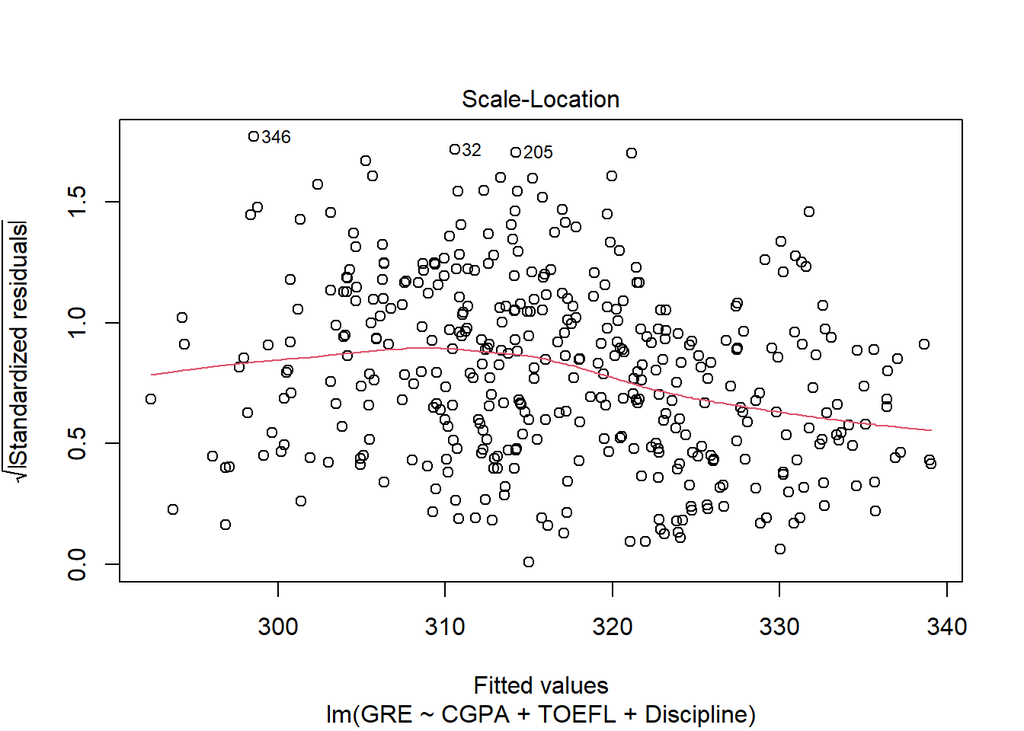

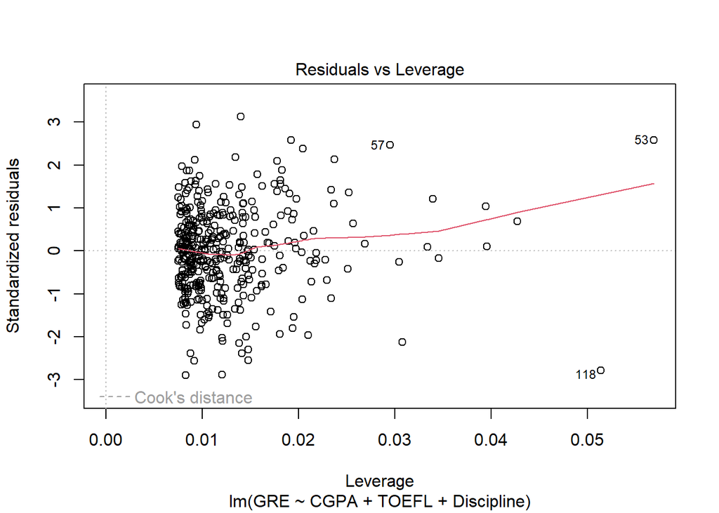

```r
plot(adm_fit3)
```

ANCOVA

```r
anova(adm_fit3)
```

```
## Analysis of Variance Table
##
## Response: GRE
##             Df Sum Sq Mean Sq   F value Pr(>F)
## CGPA         1  36453   36453 1155.7828 <2e-16 ***
## TOEFL        1   3562    3562  112.9321 <2e-16 ***
## Discipline   2     54      27    0.8514 0.4276
## Residuals  395  12458      32
## ---
## Signif. codes:  0 '***' 0.001 '**' 0.01 '*' 0.05 '.' 0.1 ' ' 1
```

Generalized linear models (GLMs) are a flexible class of models that extend the linear regression framework to a wide range of response variables, including categorical, count, and continuous data. They allow for the modeling of complex relationships between variables by using a link function to transform the response variable into a linear combination of the predictors. Generalized linear models are commonly used in various fields, including biology, economics, and psychology, to analyze data that does not meet the assumptions of traditional linear regression.

## Logistic regression

Logistic regression is a type of GLM used to model the relationship between a categorical dependent variable and one or more independent variables. Generally, there are three types of logistic regression models:

- **binary** - models the probability of a binary outcome, such as yes/no or success/failure.
- **multinomial** - models the relationship between an unordered (nominal) categorical dependent variable.
- **ordinal** - models the relationship between an ordered categorical dependent variable.

Here, we will fit a binary logistic GLM that predicts *Admit* from all available variables. To fit a binary logistic regression model we can use the `glm()` function, which can fit a series of GLMs. Like other modeling functions in `R`, we first define a model formula and provide our dataset to the `data` argument. For the `glm()` function in particular, we also provide a string to the `family` argument to indicate the type of GLM we wish to fit. You can find the list of options for the `family` argument by typing `?family` in the `R` console.

While the `glm()` function will accept a binary factor variable as the response, it is good habit to manually define the response variable. What we mean by that is to select which of the outcomes will be coded as `1` and `0`. This is important when assessing coefficients from logistic models, where the direction of the effect is as important or more important than the magnitude of that coefficient. Here, we will assign *Accepted* to `1` and *Rejected* to `0`.

```r
adm_df$Admit_logit <- ifelse(adm_df$Admit == "Accepted", 1, 0)

adm_logit <- glm(Admit_logit ~ GRE + TOEFL + SOP + LOR + CGPA + Research + Discipline, family = 'binomial', data = adm_df)

summary(adm_logit)
```

```
##
## Call:
## glm(formula = Admit_logit ~ GRE + TOEFL + SOP + LOR + CGPA +
##     Research + Discipline, family = "binomial", data = adm_df)
##
## Deviance Residuals:
##     Min       1Q   Median       3Q      Max
## -2.6852  -0.2522   0.1202   0.4654   2.4791
##
## Coefficients:
##                                        Estimate Std. Error z value Pr(>|z|)
## (Intercept)                          -48.545485   7.730934  -6.279 3.40e-10 ***
## GRE                                    0.074665   0.027978   2.669  0.00761 **
## TOEFL                                 -0.006529   0.056884  -0.115  0.90863
## SOP                                   -0.053916   0.261591  -0.206  0.83671
## LOR                                    0.813565   0.281794   2.887  0.00389 **
## CGPA                                   7.154867   1.604411   4.459 8.22e-06 ***
## Researchyes                            0.517738   0.355639   1.456  0.14545
## DisciplineHumanities and Soc Science  -0.063083   0.381344  -0.165  0.86861
## DisciplineScience & Eng                0.171649   0.624923   0.275  0.78357
## ---
## Signif. codes:  0 '***' 0.001 '**' 0.01 '*' 0.05 '.' 0.1 ' ' 1
##
## (Dispersion parameter for binomial family taken to be 1)
##
##     Null deviance: 476.24  on 399  degrees of freedom
## Residual deviance: 238.67  on 391  degrees of freedom
## AIC: 256.67
##
## Number of Fisher Scoring iterations: 7
```

```r
logit_null <- glm(Admit ~ 1, family = "binomial", data = adm_df)

logLik(adm_logit) - logLik(logit_null)
```

```
## 'log Lik.' 118.7854 (df=9)
```

## Mixed-effect linear models

Mixed effect models, also known as multilevel models or hierarchical models, are a type of regression model used to analyze data that has a nested structure or repeated measures. They account for both fixed and random effects in the data and allow for the estimation of parameters at both the individual and group levels. Mixed effect models are commonly used when observations are not independent or where individual variability needs to be taken into account.

```r
library(lme4)
library(lmerTest)

adm_lmer <- lmer(GRE ~ TOEFL + (1 | Discipline), data = adm_df)

summary(adm_lmer)
```

```
## Linear mixed model fit by REML. t-tests use Satterthwaite's method ['lmerModLmerTest']
## Formula: GRE ~ TOEFL + (1 | Discipline)
##    Data: adm_df
##
## REML criterion at convergence: 2596.6
##
## Scaled residuals:
##     Min      1Q  Median      3Q     Max
## -3.9515 -0.5703  0.0145  0.5792  2.8545
##
## Random effects:
##  Groups     Name        Variance Std.Dev.
##  Discipline (Intercept)  5.074   2.252
##  Residual               37.853   6.152
## Number of obs: 400, groups:  Discipline, 3
##
## Fixed effects:
##             Estimate Std. Error       df t value Pr(>|t|)
## (Intercept) 168.2752     7.3613 194.1918   22.86   <2e-16 ***
## TOEFL         1.3828     0.0674 303.4097   20.52   <2e-16 ***
## ---
## Signif. codes:  0 '***' 0.001 '**' 0.01 '*' 0.05 '.' 0.1 ' ' 1
##
## Correlation of Fixed Effects:
##       (Intr)
## TOEFL -0.983
```